# Risk Factor Analysis

## Outcome Variable

**Outcome Variable:** ever_swasted

## Predictor Variables

**Intervention Variable:** vagbrth

**Adjustment Set:**

unadjusted

## Stratifying Variables

The analysis was stratified on these variable(s):

- agecat
- studyid
- country

## Data Summary

| agecat | studyid | country | vagbrth | ever_swasted | n_cell | n |
| --- | --- | --- | --- | --- | --- | --- |
| 0-24 months (no birth wast) | ki1000108-CMC-V-BCS-2002 | INDIA | 0 | 0 | 20 | 368 |
| 0-24 months (no birth wast) | ki1000108-CMC-V-BCS-2002 | INDIA | 0 | 1 | 5 | 368 |
| 0-24 months (no birth wast) | ki1000108-CMC-V-BCS-2002 | INDIA | 1 | 0 | 293 | 368 |
| 0-24 months (no birth wast) | ki1000108-CMC-V-BCS-2002 | INDIA | 1 | 1 | 50 | 368 |
| 0-24 months (no birth wast) | ki1000108-IRC | INDIA | 0 | 0 | 55 | 409 |
| 0-24 months (no birth wast) | ki1000108-IRC | INDIA | 0 | 1 | 15 | 409 |
| 0-24 months (no birth wast) | ki1000108-IRC | INDIA | 1 | 0 | 277 | 409 |
| 0-24 months (no birth wast) | ki1000108-IRC | INDIA | 1 | 1 | 62 | 409 |
| 0-24 months (no birth wast) | ki1017093b-PROVIDE | BANGLADESH | 0 | 0 | 158 | 687 |
| 0-24 months (no birth wast) | ki1017093b-PROVIDE | BANGLADESH | 0 | 1 | 1 | 687 |
| 0-24 months (no birth wast) | ki1017093b-PROVIDE | BANGLADESH | 1 | 0 | 510 | 687 |
| 0-24 months (no birth wast) | ki1017093b-PROVIDE | BANGLADESH | 1 | 1 | 18 | 687 |
| 0-24 months (no birth wast) | ki1017093c-NIH-Crypto | BANGLADESH | 0 | 0 | 198 | 496 |
| 0-24 months (no birth wast) | ki1017093c-NIH-Crypto | BANGLADESH | 0 | 1 | 4 | 496 |
| 0-24 months (no birth wast) | ki1017093c-NIH-Crypto | BANGLADESH | 1 | 0 | 284 | 496 |
| 0-24 months (no birth wast) | ki1017093c-NIH-Crypto | BANGLADESH | 1 | 1 | 10 | 496 |
| 0-24 months (no birth wast) | ki1066203-TanzaniaChild2 | TANZANIA, UNITED REPUBLIC OF | 0 | 0 | 195 | 2355 |
| 0-24 months (no birth wast) | ki1066203-TanzaniaChild2 | TANZANIA, UNITED REPUBLIC OF | 0 | 1 | 17 | 2355 |
| 0-24 months (no birth wast) | ki1066203-TanzaniaChild2 | TANZANIA, UNITED REPUBLIC OF | 1 | 0 | 2039 | 2355 |
| 0-24 months (no birth wast) | ki1066203-TanzaniaChild2 | TANZANIA, UNITED REPUBLIC OF | 1 | 1 | 104 | 2355 |
| 0-24 months (no birth wast) | ki1119695-PROBIT | BELARUS | 0 | 0 | 835 | 8113 |
| 0-24 months (no birth wast) | ki1119695-PROBIT | BELARUS | 0 | 1 | 12 | 8113 |
| 0-24 months (no birth wast) | ki1119695-PROBIT | BELARUS | 1 | 0 | 7196 | 8113 |
| 0-24 months (no birth wast) | ki1119695-PROBIT | BELARUS | 1 | 1 | 70 | 8113 |
| 0-24 months (no birth wast) | ki1126311-ZVITAMBO | ZIMBABWE | 0 | 0 | 1007 | 12356 |
| 0-24 months (no birth wast) | ki1126311-ZVITAMBO | ZIMBABWE | 0 | 1 | 31 | 12356 |
| 0-24 months (no birth wast) | ki1126311-ZVITAMBO | ZIMBABWE | 1 | 0 | 10886 | 12356 |
| 0-24 months (no birth wast) | ki1126311-ZVITAMBO | ZIMBABWE | 1 | 1 | 432 | 12356 |
| 0-24 months (no birth wast) | kiGH5241-JiVitA-3 | BANGLADESH | 0 | 0 | 724 | 12953 |
| 0-24 months (no birth wast) | kiGH5241-JiVitA-3 | BANGLADESH | 0 | 1 | 17 | 12953 |

[output cut: 78 more lines]

The following strata were considered:

- agecat: 0-24 months (no birth wast), studyid: ki1000108-CMC-V-BCS-2002, country: INDIA
- agecat: 0-24 months (no birth wast), studyid: ki1000108-IRC, country: INDIA
- agecat: 0-24 months (no birth wast), studyid: ki1017093b-PROVIDE, country: BANGLADESH
- agecat: 0-24 months (no birth wast), studyid: ki1017093c-NIH-Crypto, country: BANGLADESH
- agecat: 0-24 months (no birth wast), studyid: ki1066203-TanzaniaChild2, country: TANZANIA, UNITED REPUBLIC OF
- agecat: 0-24 months (no birth wast), studyid: ki1119695-PROBIT, country: BELARUS
- agecat: 0-24 months (no birth wast), studyid: ki1126311-ZVITAMBO, country: ZIMBABWE
- agecat: 0-24 months (no birth wast), studyid: kiGH5241-JiVitA-3, country: BANGLADESH
- agecat: 0-24 months (no birth wast), studyid: kiGH5241-JiVitA-4, country: BANGLADESH
- agecat: 0-6 months (no birth wast), studyid: ki1000108-CMC-V-BCS-2002, country: INDIA
- agecat: 0-6 months (no birth wast), studyid: ki1000108-IRC, country: INDIA
- agecat: 0-6 months (no birth wast), studyid: ki1017093b-PROVIDE, country: BANGLADESH
- agecat: 0-6 months (no birth wast), studyid: ki1017093c-NIH-Crypto, country: BANGLADESH
- agecat: 0-6 months (no birth wast), studyid: ki1066203-TanzaniaChild2, country: TANZANIA, UNITED REPUBLIC OF
- agecat: 0-6 months (no birth wast), studyid: ki1119695-PROBIT, country: BELARUS
- agecat: 0-6 months (no birth wast), studyid: ki1126311-ZVITAMBO, country: ZIMBABWE
- agecat: 0-6 months (no birth wast), studyid: kiGH5241-JiVitA-3, country: BANGLADESH
- agecat: 0-6 months (no birth wast), studyid: kiGH5241-JiVitA-4, country: BANGLADESH
- agecat: 6-24 months, studyid: ki1000108-CMC-V-BCS-2002, country: INDIA
- agecat: 6-24 months, studyid: ki1000108-IRC, country: INDIA
- agecat: 6-24 months, studyid: ki1017093b-PROVIDE, country: BANGLADESH
- agecat: 6-24 months, studyid: ki1017093c-NIH-Crypto, country: BANGLADESH
- agecat: 6-24 months, studyid: ki1066203-TanzaniaChild2, country: TANZANIA, UNITED REPUBLIC OF
- agecat: 6-24 months, studyid: ki1119695-PROBIT, country: BELARUS
- agecat: 6-24 months, studyid: ki1126311-ZVITAMBO, country: ZIMBABWE
- agecat: 6-24 months, studyid: kiGH5241-JiVitA-3, country: BANGLADESH
- agecat: 6-24 months, studyid: kiGH5241-JiVitA-4, country: BANGLADESH

### Dropped Strata

Some strata were dropped due to rare outcomes:

- agecat: 0-24 months (no birth wast), studyid: ki1017093b-PROVIDE, country: BANGLADESH
- agecat: 0-24 months (no birth wast), studyid: ki1017093c-NIH-Crypto, country: BANGLADESH
- agecat: 0-24 months (no birth wast), studyid: kiGH5241-JiVitA-4, country: BANGLADESH
- agecat: 0-6 months (no birth wast), studyid: ki1000108-CMC-V-BCS-2002, country: INDIA
- agecat: 0-6 months (no birth wast), studyid: ki1017093b-PROVIDE, country: BANGLADESH
- agecat: 0-6 months (no birth wast), studyid: ki1017093c-NIH-Crypto, country: BANGLADESH
- agecat: 0-6 months (no birth wast), studyid: ki1126311-ZVITAMBO, country: ZIMBABWE
- agecat: 0-6 months (no birth wast), studyid: kiGH5241-JiVitA-4, country: BANGLADESH
- agecat: 6-24 months, studyid: ki1000108-CMC-V-BCS-2002, country: INDIA
- agecat: 6-24 months, studyid: ki1000108-IRC, country: INDIA
- agecat: 6-24 months, studyid: ki1017093b-PROVIDE, country: BANGLADESH
- agecat: 6-24 months, studyid: ki1017093c-NIH-Crypto, country: BANGLADESH
- agecat: 6-24 months, studyid: ki1119695-PROBIT, country: BELARUS
- agecat: 6-24 months, studyid: kiGH5241-JiVitA-4, country: BANGLADESH

## Methods Detail

We’re interested in the causal parameters $E[Y_a]$ for all values of $a \in \mathcal{A}$. These parameters represent the mean outcome if, possibly contrary to fact, we intervened to set all units to have $A=a$. Under the randomization and positivity assumptions, these are identified by the statistical parameters $\psi_a=E_W[E_{Y|A,W}(Y|A=a,W)]$. In addition, we’re interested in the mean of $Y$, $E[Y]$ under no intervention (the observed mean). We will estimate these parameters by using SuperLearner to fit the relevant likelihood factors – $E_{Y|A,W}(Y|A=a,W)$ and $p(A=a|W)$, and then updating our likelihood fit using a joint TMLE.

For unadjusted analyses ($W=\{\}$), initial likelihoods were estimated using Lrnr_glm to estimate the simple $E(Y|A)$ and Lrnr_mean to estimate $p(A)$. For adjusted analyses, a small library containing Lrnr_glmnet, Lrnr_xgboost, and Lrnr_mean was used.

Having estimated these parameters, we will then use the delta method to estimate relative risks and attributable risks relative to a prespecified baseline level of $A$.

# Results Detail

## Results Plots

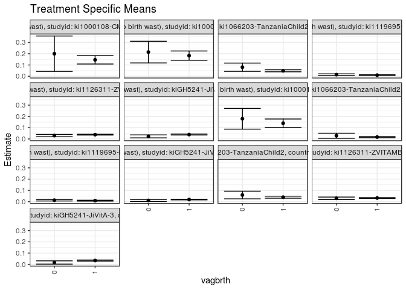

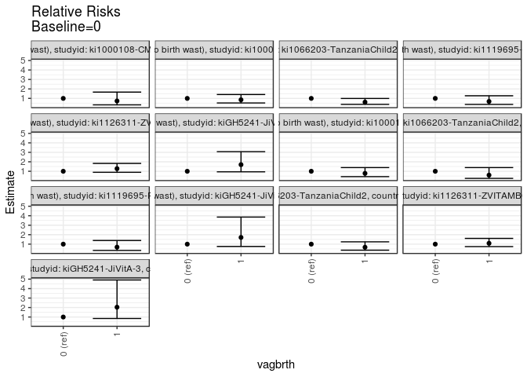

[figure not shown]

[figure not shown]

## Results Table

### Parameter: TSM

| agecat | studyid | country | intervention_level | baseline_level | estimate | ci_lower | ci_upper |
| --- | --- | --- | --- | --- | --- | --- | --- |
| 0-24 months (no birth wast) | ki1000108-CMC-V-BCS-2002 | INDIA | 0 | NA | 0.2000000 | 0.0429894 | 0.3570106 |
| 0-24 months (no birth wast) | ki1000108-CMC-V-BCS-2002 | INDIA | 1 | NA | 0.1457726 | 0.1083773 | 0.1831679 |
| 0-24 months (no birth wast) | ki1000108-IRC | INDIA | 0 | NA | 0.2142857 | 0.1180448 | 0.3105266 |
| 0-24 months (no birth wast) | ki1000108-IRC | INDIA | 1 | NA | 0.1828909 | 0.1416891 | 0.2240926 |
| 0-24 months (no birth wast) | ki1066203-TanzaniaChild2 | TANZANIA, UNITED REPUBLIC OF | 0 | NA | 0.0801887 | 0.0436226 | 0.1167547 |
| 0-24 months (no birth wast) | ki1066203-TanzaniaChild2 | TANZANIA, UNITED REPUBLIC OF | 1 | NA | 0.0485301 | 0.0394303 | 0.0576299 |
| 0-24 months (no birth wast) | ki1119695-PROBIT | BELARUS | 0 | NA | 0.0141677 | 0.0069844 | 0.0213509 |
| 0-24 months (no birth wast) | ki1119695-PROBIT | BELARUS | 1 | NA | 0.0096339 | 0.0061785 | 0.0130894 |
| 0-24 months (no birth wast) | ki1126311-ZVITAMBO | ZIMBABWE | 0 | NA | 0.0298651 | 0.0195098 | 0.0402205 |
| 0-24 months (no birth wast) | ki1126311-ZVITAMBO | ZIMBABWE | 1 | NA | 0.0381693 | 0.0346392 | 0.0416994 |
| 0-24 months (no birth wast) | kiGH5241-JiVitA-3 | BANGLADESH | 0 | NA | 0.0229420 | 0.0097798 | 0.0361041 |
| 0-24 months (no birth wast) | kiGH5241-JiVitA-3 | BANGLADESH | 1 | NA | 0.0389781 | 0.0349534 | 0.0430027 |
| 0-6 months (no birth wast) | ki1000108-IRC | INDIA | 0 | NA | 0.1791045 | 0.0871728 | 0.2710362 |
| 0-6 months (no birth wast) | ki1000108-IRC | INDIA | 1 | NA | 0.1393189 | 0.1015068 | 0.1771310 |
| 0-6 months (no birth wast) | ki1066203-TanzaniaChild2 | TANZANIA, UNITED REPUBLIC OF | 0 | NA | 0.0284360 | 0.0060039 | 0.0508681 |
| 0-6 months (no birth wast) | ki1066203-TanzaniaChild2 | TANZANIA, UNITED REPUBLIC OF | 1 | NA | 0.0168539 | 0.0113938 | 0.0223140 |
| 0-6 months (no birth wast) | ki1119695-PROBIT | BELARUS | 0 | NA | 0.0131108 | 0.0062476 | 0.0199741 |
| 0-6 months (no birth wast) | ki1119695-PROBIT | BELARUS | 1 | NA | 0.0089636 | 0.0050175 | 0.0129097 |
| 0-6 months (no birth wast) | kiGH5241-JiVitA-3 | BANGLADESH | 0 | NA | 0.0110041 | 0.0022478 | 0.0197605 |
| 0-6 months (no birth wast) | kiGH5241-JiVitA-3 | BANGLADESH | 1 | NA | 0.0188054 | 0.0158966 | 0.0217143 |
| 6-24 months | ki1066203-TanzaniaChild2 | TANZANIA, UNITED REPUBLIC OF | 0 | NA | 0.0591398 | 0.0252317 | 0.0930478 |
| 6-24 months | ki1066203-TanzaniaChild2 | TANZANIA, UNITED REPUBLIC OF | 1 | NA | 0.0397790 | 0.0307730 | 0.0487850 |
| 6-24 months | ki1126311-ZVITAMBO | ZIMBABWE | 0 | NA | 0.0298673 | 0.0187705 | 0.0409641 |
| 6-24 months | ki1126311-ZVITAMBO | ZIMBABWE | 1 | NA | 0.0325740 | 0.0290413 | 0.0361066 |
| 6-24 months | kiGH5241-JiVitA-3 | BANGLADESH | 0 | NA | 0.0166667 | 0.0022538 | 0.0310795 |
| 6-24 months | kiGH5241-JiVitA-3 | BANGLADESH | 1 | NA | 0.0339769 | 0.0294996 | 0.0384543 |

### Parameter: E(Y)

| agecat | studyid | country | intervention_level | baseline_level | estimate | ci_lower | ci_upper |
| --- | --- | --- | --- | --- | --- | --- | --- |
| 0-24 months (no birth wast) | ki1000108-CMC-V-BCS-2002 | INDIA | NA | NA | 0.1494565 | 0.1129794 | 0.1859337 |
| 0-24 months (no birth wast) | ki1000108-IRC | INDIA | NA | NA | 0.1882641 | 0.1503318 | 0.2261964 |
| 0-24 months (no birth wast) | ki1066203-TanzaniaChild2 | TANZANIA, UNITED REPUBLIC OF | NA | NA | 0.0513800 | 0.0424616 | 0.0602985 |
| 0-24 months (no birth wast) | ki1119695-PROBIT | BELARUS | NA | NA | 0.0101072 | 0.0069537 | 0.0132608 |
| 0-24 months (no birth wast) | ki1126311-ZVITAMBO | ZIMBABWE | NA | NA | 0.0374717 | 0.0341229 | 0.0408204 |
| 0-24 months (no birth wast) | kiGH5241-JiVitA-3 | BANGLADESH | NA | NA | 0.0380607 | 0.0342582 | 0.0418631 |
| 0-6 months (no birth wast) | ki1000108-IRC | INDIA | NA | NA | 0.1461538 | 0.1110489 | 0.1812588 |
| 0-6 months (no birth wast) | ki1066203-TanzaniaChild2 | TANZANIA, UNITED REPUBLIC OF | NA | NA | 0.0178952 | 0.0125307 | 0.0232597 |
| 0-6 months (no birth wast) | ki1119695-PROBIT | BELARUS | NA | NA | 0.0093997 | 0.0058450 | 0.0129543 |
| 0-6 months (no birth wast) | kiGH5241-JiVitA-3 | BANGLADESH | NA | NA | 0.0183622 | 0.0155854 | 0.0211391 |
| 6-24 months | ki1066203-TanzaniaChild2 | TANZANIA, UNITED REPUBLIC OF | NA | NA | 0.0415832 | 0.0328230 | 0.0503433 |
| 6-24 months | ki1126311-ZVITAMBO | ZIMBABWE | NA | NA | 0.0323432 | 0.0289761 | 0.0357104 |
| 6-24 months | kiGH5241-JiVitA-3 | BANGLADESH | NA | NA | 0.0328793 | 0.0286184 | 0.0371402 |

### Parameter: RR

| agecat | studyid | country | intervention_level | baseline_level | estimate | ci_lower | ci_upper |
| --- | --- | --- | --- | --- | --- | --- | --- |
| 0-24 months (no birth wast) | ki1000108-CMC-V-BCS-2002 | INDIA | 0 | 0 | 1.0000000 | 1.0000000 | 1.0000000 |
| 0-24 months (no birth wast) | ki1000108-CMC-V-BCS-2002 | INDIA | 1 | 0 | 0.7288630 | 0.3191248 | 1.6646817 |
| 0-24 months (no birth wast) | ki1000108-IRC | INDIA | 0 | 0 | 1.0000000 | 1.0000000 | 1.0000000 |
| 0-24 months (no birth wast) | ki1000108-IRC | INDIA | 1 | 0 | 0.8534907 | 0.5163975 | 1.4106310 |
| 0-24 months (no birth wast) | ki1066203-TanzaniaChild2 | TANZANIA, UNITED REPUBLIC OF | 0 | 0 | 1.0000000 | 1.0000000 | 1.0000000 |
| 0-24 months (no birth wast) | ki1066203-TanzaniaChild2 | TANZANIA, UNITED REPUBLIC OF | 1 | 0 | 0.6051989 | 0.3696326 | 0.9908911 |
| 0-24 months (no birth wast) | ki1119695-PROBIT | BELARUS | 0 | 0 | 1.0000000 | 1.0000000 | 1.0000000 |
| 0-24 months (no birth wast) | ki1119695-PROBIT | BELARUS | 1 | 0 | 0.6799936 | 0.3618497 | 1.2778544 |
| 0-24 months (no birth wast) | ki1126311-ZVITAMBO | ZIMBABWE | 0 | 0 | 1.0000000 | 1.0000000 | 1.0000000 |
| 0-24 months (no birth wast) | ki1126311-ZVITAMBO | ZIMBABWE | 1 | 0 | 1.2780555 | 0.8926862 | 1.8297873 |
| 0-24 months (no birth wast) | kiGH5241-JiVitA-3 | BANGLADESH | 0 | 0 | 1.0000000 | 1.0000000 | 1.0000000 |
| 0-24 months (no birth wast) | kiGH5241-JiVitA-3 | BANGLADESH | 1 | 0 | 1.6989846 | 0.9404395 | 3.0693613 |
| 0-6 months (no birth wast) | ki1000108-IRC | INDIA | 0 | 0 | 1.0000000 | 1.0000000 | 1.0000000 |
| 0-6 months (no birth wast) | ki1000108-IRC | INDIA | 1 | 0 | 0.7778638 | 0.4352533 | 1.3901609 |
| 0-6 months (no birth wast) | ki1066203-TanzaniaChild2 | TANZANIA, UNITED REPUBLIC OF | 0 | 0 | 1.0000000 | 1.0000000 | 1.0000000 |
| 0-6 months (no birth wast) | ki1066203-TanzaniaChild2 | TANZANIA, UNITED REPUBLIC OF | 1 | 0 | 0.5926966 | 0.2526208 | 1.3905792 |
| 0-6 months (no birth wast) | ki1119695-PROBIT | BELARUS | 0 | 0 | 1.0000000 | 1.0000000 | 1.0000000 |
| 0-6 months (no birth wast) | ki1119695-PROBIT | BELARUS | 1 | 0 | 0.6836771 | 0.3371783 | 1.3862529 |
| 0-6 months (no birth wast) | kiGH5241-JiVitA-3 | BANGLADESH | 0 | 0 | 1.0000000 | 1.0000000 | 1.0000000 |
| 0-6 months (no birth wast) | kiGH5241-JiVitA-3 | BANGLADESH | 1 | 0 | 1.7089408 | 0.7567499 | 3.8592392 |
| 6-24 months | ki1066203-TanzaniaChild2 | TANZANIA, UNITED REPUBLIC OF | 0 | 0 | 1.0000000 | 1.0000000 | 1.0000000 |
| 6-24 months | ki1066203-TanzaniaChild2 | TANZANIA, UNITED REPUBLIC OF | 1 | 0 | 0.6726268 | 0.3631281 | 1.2459153 |
| 6-24 months | ki1126311-ZVITAMBO | ZIMBABWE | 0 | 0 | 1.0000000 | 1.0000000 | 1.0000000 |
| 6-24 months | ki1126311-ZVITAMBO | ZIMBABWE | 1 | 0 | 1.0906245 | 0.7406023 | 1.6060736 |
| 6-24 months | kiGH5241-JiVitA-3 | BANGLADESH | 0 | 0 | 1.0000000 | 1.0000000 | 1.0000000 |
| 6-24 months | kiGH5241-JiVitA-3 | BANGLADESH | 1 | 0 | 2.0386157 | 0.8464296 | 4.9099816 |

### Parameter: PAR

| agecat | studyid | country | intervention_level | baseline_level | estimate | ci_lower | ci_upper |
| --- | --- | --- | --- | --- | --- | --- | --- |
| 0-24 months (no birth wast) | ki1000108-CMC-V-BCS-2002 | INDIA | 0 | NA | -0.0505435 | -0.2009875 | 0.0999006 |
| 0-24 months (no birth wast) | ki1000108-IRC | INDIA | 0 | NA | -0.0260217 | -0.1128012 | 0.0607579 |
| 0-24 months (no birth wast) | ki1066203-TanzaniaChild2 | TANZANIA, UNITED REPUBLIC OF | 0 | NA | -0.0288086 | -0.0630998 | 0.0054825 |
| 0-24 months (no birth wast) | ki1119695-PROBIT | BELARUS | 0 | NA | -0.0040604 | -0.0112927 | 0.0031719 |
| 0-24 months (no birth wast) | ki1126311-ZVITAMBO | ZIMBABWE | 0 | NA | 0.0076065 | -0.0024150 | 0.0176281 |
| 0-24 months (no birth wast) | kiGH5241-JiVitA-3 | BANGLADESH | 0 | NA | 0.0151187 | 0.0018410 | 0.0283965 |
| 0-6 months (no birth wast) | ki1000108-IRC | INDIA | 0 | NA | -0.0329506 | -0.1152912 | 0.0493899 |
| 0-6 months (no birth wast) | ki1066203-TanzaniaChild2 | TANZANIA, UNITED REPUBLIC OF | 0 | NA | -0.0105408 | -0.0315527 | 0.0104710 |
| 0-6 months (no birth wast) | ki1119695-PROBIT | BELARUS | 0 | NA | -0.0037112 | -0.0109991 | 0.0035768 |
| 0-6 months (no birth wast) | kiGH5241-JiVitA-3 | BANGLADESH | 0 | NA | 0.0073581 | -0.0014173 | 0.0161335 |
| 6-24 months | ki1066203-TanzaniaChild2 | TANZANIA, UNITED REPUBLIC OF | 0 | NA | -0.0175566 | -0.0493719 | 0.0142587 |
| 6-24 months | ki1126311-ZVITAMBO | ZIMBABWE | 0 | NA | 0.0024760 | -0.0081769 | 0.0131288 |
| 6-24 months | kiGH5241-JiVitA-3 | BANGLADESH | 0 | NA | 0.0162126 | 0.0019582 | 0.0304670 |

### Parameter: PAF

| agecat | studyid | country | intervention_level | baseline_level | estimate | ci_lower | ci_upper |
| --- | --- | --- | --- | --- | --- | --- | --- |
| 0-24 months (no birth wast) | ki1000108-CMC-V-BCS-2002 | INDIA | 0 | NA | -0.3381818 | -1.8354235 | 0.3684433 |
| 0-24 months (no birth wast) | ki1000108-IRC | INDIA | 0 | NA | -0.1382189 | -0.7058900 | 0.2405476 |
| 0-24 months (no birth wast) | ki1066203-TanzaniaChild2 | TANZANIA, UNITED REPUBLIC OF | 0 | NA | -0.5606970 | -1.3844507 | -0.0215247 |
| 0-24 months (no birth wast) | ki1119695-PROBIT | BELARUS | 0 | NA | -0.4017335 | -1.4016111 | 0.1818588 |
| 0-24 months (no birth wast) | ki1126311-ZVITAMBO | ZIMBABWE | 0 | NA | 0.2029946 | -0.1139815 | 0.4297773 |
| 0-24 months (no birth wast) | kiGH5241-JiVitA-3 | BANGLADESH | 0 | NA | 0.3972265 | -0.0669600 | 0.6594662 |
| 0-6 months (no birth wast) | ki1000108-IRC | INDIA | 0 | NA | -0.2254517 | -0.9382973 | 0.2252314 |
| 0-6 months (no birth wast) | ki1066203-TanzaniaChild2 | TANZANIA, UNITED REPUBLIC OF | 0 | NA | -0.5890318 | -2.3006805 | 0.2349995 |
| 0-6 months (no birth wast) | ki1119695-PROBIT | BELARUS | 0 | NA | -0.3948192 | -1.5484619 | 0.2365902 |
| 0-6 months (no birth wast) | kiGH5241-JiVitA-3 | BANGLADESH | 0 | NA | 0.4007200 | -0.3166493 | 0.7272344 |
| 6-24 months | ki1066203-TanzaniaChild2 | TANZANIA, UNITED REPUBLIC OF | 0 | NA | -0.4222049 | -1.4277873 | 0.1668681 |
| 6-24 months | ki1126311-ZVITAMBO | ZIMBABWE | 0 | NA | 0.0765532 | -0.3190784 | 0.3535229 |
| 6-24 months | kiGH5241-JiVitA-3 | BANGLADESH | 0 | NA | 0.4930952 | -0.1864679 | 0.7834307 |